# Insurance Model

Mary Anna Kivenson

April 18, 2020

## Data Exploration

#### Read Data

Here, we read the training dataset into a dataframe.

```r
df <- read.csv("https://raw.githubusercontent.com/mkivenson/Business-Analytics-Data-Mining/master/Insurance%20Model/insurance_training_data.csv")[-1]


head(df)
```

```
##   TARGET_FLAG TARGET_AMT KIDSDRIV AGE HOMEKIDS YOJ   INCOME PARENT1 HOME_VAL
## 1           0          0        0  60        0  11  $67,349      No       $0
## 2           0          0        0  43        0  11  $91,449      No $257,252
## 3           0          0        0  35        1  10  $16,039      No $124,191
## 4           0          0        0  51        0  14               No $306,251
## 5           0          0        0  50        0  NA $114,986      No $243,925
## 6           1       2946        0  34        1  12 $125,301     Yes       $0
##   MSTATUS SEX     EDUCATION           JOB TRAVTIME    CAR_USE BLUEBOOK TIF
## 1    z_No   M           PhD  Professional       14    Private  $14,230  11
## 2    z_No   M z_High School z_Blue Collar       22 Commercial  $14,940   1
## 3     Yes z_F z_High School      Clerical        5    Private   $4,010   4
## 4     Yes   M  <High School z_Blue Collar       32    Private  $15,440   7
## 5     Yes z_F           PhD        Doctor       36    Private  $18,000   1
## 6    z_No z_F     Bachelors z_Blue Collar       46 Commercial  $17,430   1
##     CAR_TYPE RED_CAR OLDCLAIM CLM_FREQ REVOKED MVR_PTS CAR_AGE
## 1    Minivan     yes   $4,461        2      No       3      18
## 2    Minivan     yes       $0        0      No       0       1
## 3      z_SUV      no  $38,690        2      No       3      10
## 4    Minivan     yes       $0        0      No       0       6
## 5      z_SUV      no  $19,217        2     Yes       3      17
## 6 Sports Car      no       $0        0      No       0       7
##            URBANICITY
## 1 Highly Urban/ Urban
## 2 Highly Urban/ Urban
## 3 Highly Urban/ Urban
## 4 Highly Urban/ Urban
## 5 Highly Urban/ Urban
## 6 Highly Urban/ Urban
```

```r
df_eval <- read.csv("https://raw.githubusercontent.com/mkivenson/Business-Analytics-Data-Mining/master/Insurance%20Model/insurance-evaluation-data.csv")[-1]
head(df_eval)
```

```
##   TARGET_FLAG TARGET_AMT KIDSDRIV AGE HOMEKIDS YOJ  INCOME PARENT1 HOME_VAL
## 1          NA         NA        0  48        0  11 $52,881      No       $0
## 2          NA         NA        1  40        1  11 $50,815     Yes       $0
## 3          NA         NA        0  44        2  12 $43,486     Yes       $0
## 4          NA         NA        0  35        2  NA $21,204     Yes       $0
## 5          NA         NA        0  59        0  12 $87,460      No       $0
## 6          NA         NA        0  46        0  14              No $207,519
##   MSTATUS SEX     EDUCATION           JOB TRAVTIME    CAR_USE BLUEBOOK TIF
## 1    z_No   M     Bachelors       Manager       26    Private  $21,970   1
## 2    z_No   M z_High School       Manager       21    Private  $18,930   6
## 3    z_No z_F z_High School z_Blue Collar       30 Commercial   $5,900  10
## 4    z_No   M z_High School      Clerical       74    Private   $9,230   6
## 5    z_No   M z_High School       Manager       45    Private  $15,420   1
## 6     Yes   M     Bachelors  Professional        7 Commercial  $25,660   1
##      CAR_TYPE RED_CAR OLDCLAIM CLM_FREQ REVOKED MVR_PTS CAR_AGE
## 1         Van     yes       $0        0      No       2      10
## 2     Minivan      no   $3,295        1      No       2       1
## 3       z_SUV      no       $0        0      No       0      10
## 4      Pickup      no       $0        0     Yes       0       4
## 5     Minivan     yes  $44,857        2      No       4       1
## 6 Panel Truck      no   $2,119        1      No       2      12
##              URBANICITY
## 1   Highly Urban/ Urban
## 2   Highly Urban/ Urban
## 3 z_Highly Rural/ Rural
## 4 z_Highly Rural/ Rural
## 5   Highly Urban/ Urban
## 6   Highly Urban/ Urban
```

```r
df$INCOME <- as.numeric(df$INCOME)
df$HOME_VAL <- as.numeric(df$HOME_VAL)
df$BLUEBOOK <- as.numeric(df$BLUEBOOK)
df$OLDCLAIM <- as.numeric(df$OLDCLAIM)

# correct the evaluaton data set too
df_eval$INCOME <- as.numeric(df_eval$INCOME)
df_eval$HOME_VAL <- as.numeric(df_eval$HOME_VAL)
df_eval$BLUEBOOK <- as.numeric(df_eval$BLUEBOOK)
df_eval$OLDCLAIM <- as.numeric(df_eval$OLDCLAIM)
```

#### Summary

First, we take a look at a summary of the data.

```r
summary(df)
```

```
##   TARGET_FLAG       TARGET_AMT        KIDSDRIV           AGE
##  Min.   :0.0000   Min.   :     0   Min.   :0.0000   Min.   :16.00
##  1st Qu.:0.0000   1st Qu.:     0   1st Qu.:0.0000   1st Qu.:39.00
##  Median :0.0000   Median :     0   Median :0.0000   Median :45.00
##  Mean   :0.2638   Mean   :  1504   Mean   :0.1711   Mean   :44.79
##  3rd Qu.:1.0000   3rd Qu.:  1036   3rd Qu.:0.0000   3rd Qu.:51.00
##  Max.   :1.0000   Max.   :107586   Max.   :4.0000   Max.   :81.00
##                                                     NA's   :6
##     HOMEKIDS           YOJ           INCOME     PARENT1       HOME_VAL
##  Min.   :0.0000   Min.   : 0.0   Min.   :   1   No :7084   Min.   :   1
##  1st Qu.:0.0000   1st Qu.: 9.0   1st Qu.: 926   Yes:1077   1st Qu.:   2
##  Median :0.0000   Median :11.0   Median :2817              Median :1245
##  Mean   :0.7212   Mean   :10.5   Mean   :2876              Mean   :1685
##  3rd Qu.:1.0000   3rd Qu.:13.0   3rd Qu.:4701              3rd Qu.:3164
##  Max.   :5.0000   Max.   :23.0   Max.   :6613              Max.   :5107
##                   NA's   :454
##  MSTATUS      SEX               EDUCATION               JOB
##  Yes :4894   M  :3786   <High School :1203   z_Blue Collar:1825
##  z_No:3267   z_F:4375   Bachelors    :2242   Clerical     :1271
##                         Masters      :1658   Professional :1117
##                         PhD          : 728   Manager      : 988
##                         z_High School:2330   Lawyer       : 835
##                                              Student      : 712
##                                              (Other)      :1413
##     TRAVTIME            CAR_USE        BLUEBOOK         TIF
##  Min.   :  5.00   Commercial:3029   Min.   :   1   Min.   : 1.000
##  1st Qu.: 22.00   Private   :5132   1st Qu.: 478   1st Qu.: 1.000
##  Median : 33.00                     Median :1124   Median : 4.000
##  Mean   : 33.49                     Mean   :1284   Mean   : 5.351
##  3rd Qu.: 44.00                     3rd Qu.:2234   3rd Qu.: 7.000
##  Max.   :142.00                     Max.   :2789   Max.   :25.000
##
##         CAR_TYPE    RED_CAR       OLDCLAIM         CLM_FREQ      REVOKED
##  Minivan    :2145   no :5783   Min.   :   1.0   Min.   :0.0000   No :7161
##  Panel Truck: 676   yes:2378   1st Qu.:   1.0   1st Qu.:0.0000   Yes:1000
##  Pickup     :1389              Median :   1.0   Median :0.0000
##  Sports Car : 907              Mean   : 552.3   Mean   :0.7986
##  Van        : 750              3rd Qu.:1015.0   3rd Qu.:2.0000
##  z_SUV      :2294              Max.   :2857.0   Max.   :5.0000
##
##     MVR_PTS          CAR_AGE                       URBANICITY
##  Min.   : 0.000   Min.   :-3.000   Highly Urban/ Urban  :6492
##  1st Qu.: 0.000   1st Qu.: 1.000   z_Highly Rural/ Rural:1669
##  Median : 1.000   Median : 8.000
##  Mean   : 1.696   Mean   : 8.328
##  3rd Qu.: 3.000   3rd Qu.:12.000
##  Max.   :13.000   Max.   :28.000
##                   NA's   :510
```

#### Distributions

Taking a look a the distributions of numerical variables, the following items observations are revealed:

- Most of the variables are not normally distributed - features will be centered and scaled as part of the preprocessing.
- OLDCLAIM values (past payouts) are mostly 0

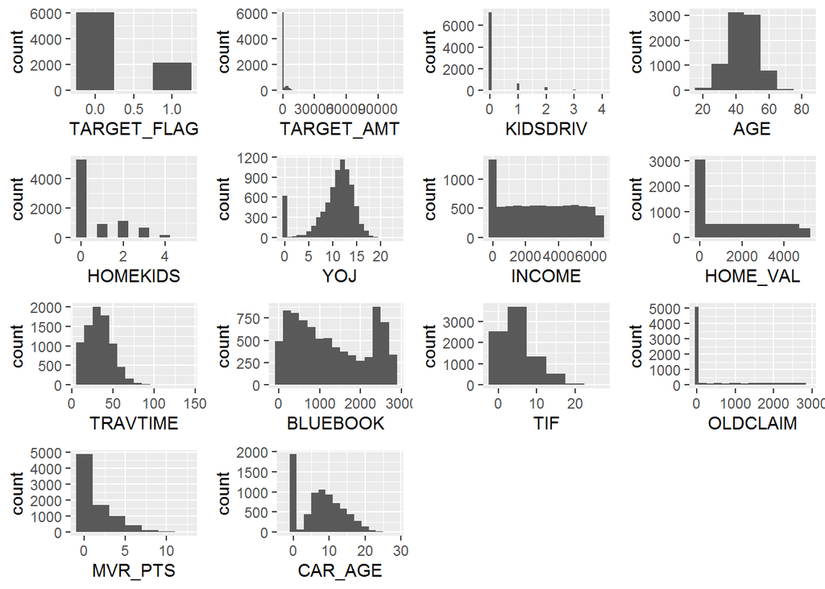

```r
grid.arrange(ggplot(df, aes(TARGET_FLAG)) + geom_histogram(binwidth = .5),
             ggplot(df, aes(TARGET_AMT)) + geom_histogram(binwidth = 1000),
             ggplot(df, aes(KIDSDRIV)) + geom_histogram(binwidth = .1),
             ggplot(df, aes(AGE)) + geom_histogram(binwidth = 10),
             ggplot(df, aes(HOMEKIDS)) + geom_histogram(binwidth = .5),
             ggplot(df, aes(YOJ)) + geom_histogram(binwidth = 1),
             ggplot(df, aes(INCOME)) + geom_histogram(binwidth = 500),
             ggplot(df, aes(HOME_VAL)) + geom_histogram(binwidth = 500),
             ggplot(df, aes(TRAVTIME)) + geom_histogram(binwidth = 10),
             ggplot(df, aes(BLUEBOOK)) + geom_histogram(binwidth = 200),
             ggplot(df, aes(TIF)) + geom_histogram(binwidth = 5),
             ggplot(df, aes(OLDCLAIM)) + geom_histogram(binwidth = 100),
             ggplot(df, aes(MVR_PTS)) + geom_histogram(binwidth = 2),
             ggplot(df, aes(CAR_AGE)) + geom_histogram(binwidth = 2),
             ncol=4)
```

#### Boxplots

For the classification task, it might be insightful to compare distributions of numerical features for the levels of `TARGET_FLAG`. It appears that the features that differ the most between levels of TARGET_FLAG are `HOME_VAL`, `OLDCLAIM`, and `MVR_PTS`.

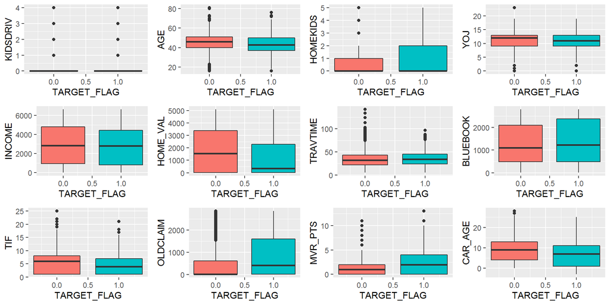

```r
grid.arrange(ggplot(df, aes(x = TARGET_FLAG, y = KIDSDRIV, fill = as.factor(TARGET_FLAG))) + geom_boxplot() + theme(legend.position = "none") ,
             ggplot(df, aes(x = TARGET_FLAG, y = AGE, fill = as.factor(TARGET_FLAG))) + geom_boxplot() + theme(legend.position = "none") ,
             ggplot(df, aes(x = TARGET_FLAG, y = HOMEKIDS, fill = as.factor(TARGET_FLAG))) + geom_boxplot() + theme(legend.position = "none") ,
             ggplot(df, aes(x = TARGET_FLAG, y = YOJ, fill = as.factor(TARGET_FLAG))) + geom_boxplot() + theme(legend.position = "none") ,
             ggplot(df, aes(x = TARGET_FLAG, y = INCOME, fill = as.factor(TARGET_FLAG))) + geom_boxplot() + theme(legend.position = "none") ,
             ggplot(df, aes(x = TARGET_FLAG, y = HOME_VAL, fill = as.factor(TARGET_FLAG))) + geom_boxplot() + theme(legend.position = "none") ,
             ggplot(df, aes(x = TARGET_FLAG, y = TRAVTIME, fill = as.factor(TARGET_FLAG))) + geom_boxplot() + theme(legend.position = "none") ,
             ggplot(df, aes(x = TARGET_FLAG, y = BLUEBOOK, fill = as.factor(TARGET_FLAG))) + geom_boxplot() + theme(legend.position = "none") ,
             ggplot(df, aes(x = TARGET_FLAG, y = TIF, fill = as.factor(TARGET_FLAG))) + geom_boxplot() + theme(legend.position = "none") ,
             ggplot(df, aes(x = TARGET_FLAG, y = OLDCLAIM, fill = as.factor(TARGET_FLAG))) + geom_boxplot() + theme(legend.position = "none") ,
             ggplot(df, aes(x = TARGET_FLAG, y = MVR_PTS, fill = as.factor(TARGET_FLAG))) + geom_boxplot() + theme(legend.position = "none") ,
             ggplot(df, aes(x = TARGET_FLAG, y = CAR_AGE, fill = as.factor(TARGET_FLAG))) + geom_boxplot() + theme(legend.position = "none") ,
             ncol=4)
```

#### Correlations

Looking at a correlation plot of numeric variables, it is evident that there is some collinearity in the dataset.

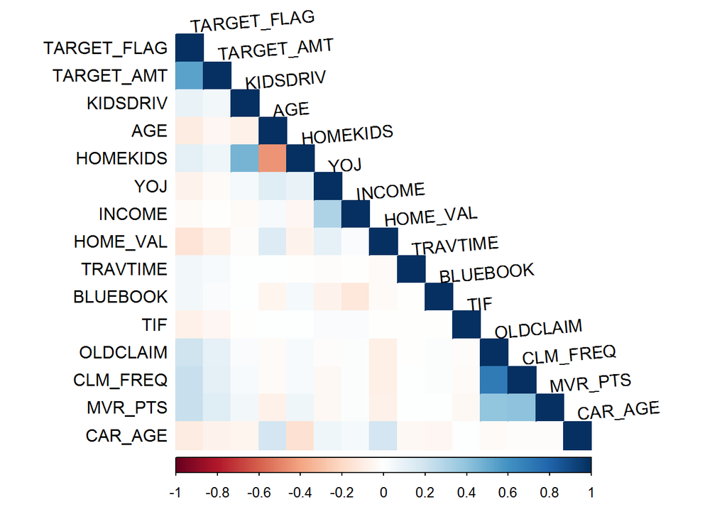

```r
corrplot(cor(df[,sapply(df, is.numeric)], use = "complete.obs"), method="color", type="lower", tl.col = "black", tl.srt = 5)
```

## Data Preparation

Based on information gathered by performing exploratory data analysis, we must impute missing values, encode categorical variables, and apply feature transformations.

#### Missing Values

We will use Multivariable Imputation by Chained Equations (mice) to fill the missing variables.

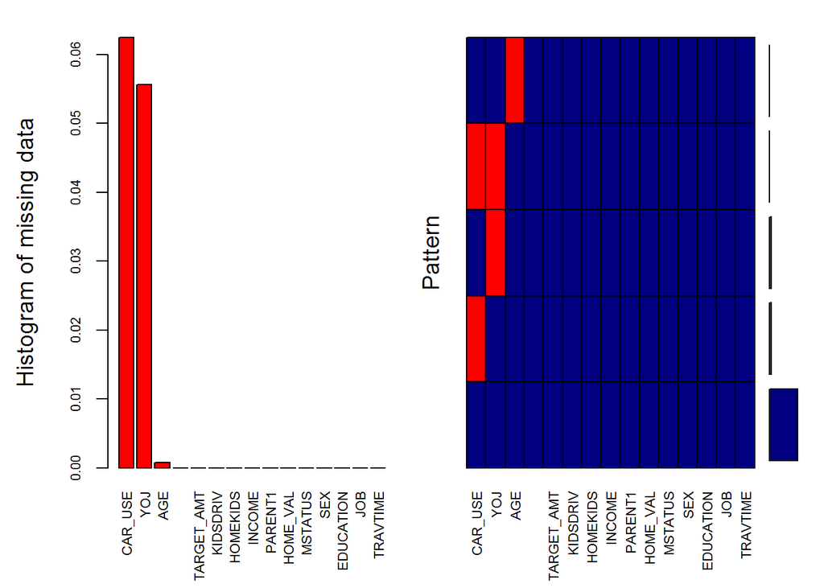

```
##
##  Variables sorted by number of missings:
##     Variable       Count
##      CAR_USE 0.062492342
##          YOJ 0.055630437
##          AGE 0.000735204
##  TARGET_FLAG 0.000000000
##   TARGET_AMT 0.000000000
##     KIDSDRIV 0.000000000
##     HOMEKIDS 0.000000000
##       INCOME 0.000000000
##      PARENT1 0.000000000
##     HOME_VAL 0.000000000
##      MSTATUS 0.000000000
##          SEX 0.000000000
##    EDUCATION 0.000000000
##          JOB 0.000000000
##     TRAVTIME 0.000000000
```

```r
aggr(df[,sapply(df, is.numeric)], col=c('navyblue','red'), numbers=TRUE, sortVars=TRUE, labels=names(df), cex.axis=.7, gap=3, ylab=c("Histogram of missing data","Pattern"))
```

#### Encoding

```r
dmy <- dummyVars(" ~ .", data = df)
df <- data.frame(predict(dmy, newdata = df))

# encode the evaluation data set too
df_eval <- data.frame(predict(dmy, newdata = df_eval))
```

Taking a look at the new columns in the dataframe, it is clear that some columns are unneccesary. Since each categorical feature requires one less column than categories, we will drop one dummy column for each feature.

```r
head(df)
```

```
##   TARGET_FLAG TARGET_AMT KIDSDRIV AGE HOMEKIDS YOJ INCOME PARENT1.No
## 1           0          0        0  60        0  11   5033          1
## 2           0          0        0  43        0  11   6292          1
## 3           0          0        0  35        1  10   1250          1
## 4           0          0        0  51        0  14      1          1
## 5           0          0        0  50        0   5    509          1
## 6           1       2946        0  34        1  12    746          0
##   PARENT1.Yes HOME_VAL MSTATUS.Yes MSTATUS.z_No SEX.M SEX.z_F
## 1           0        2           0            1     1       0
## 2           0     3259           0            1     1       0
## 3           0      348           1            0     0       1
## 4           0     3917           1            0     1       0
## 5           0     3034           1            0     0       1
## 6           1        2           0            1     0       1
##   EDUCATION..High.School EDUCATION.Bachelors EDUCATION.Masters EDUCATION.PhD
```

[output cut: 55 more lines]

```r
#names(df)
```

```r
drop <-  c("PARENT1.No", "MSTATUS.z_No", "SEX.M", "EDUCATION.z_High.School", "JOB.", "CAR_USE.Commercial", "CAR_TYPE.Pickup", "RED_CAR.no", "REVOKED.No", "URBANICITY.z_Highly.Rural..Rural")
df = df[,!(names(df) %in% drop)]


drop_eval <-  c("TARGET_FLAGFALSE" ,"TARGET_FLAGTRUE" , "TARGET_AMTFALSE", "TARGET_AMTTRUE", "PARENT1.No", "MSTATUS.z_No", "SEX.M", "EDUCATION.z_High.School", "JOB.", "CAR_USE.Commercial", "CAR_TYPE.Pickup", "RED_CAR.no", "REVOKED.No", "URBANICITY.z_Highly.Rural..Rural")
df = df[,!(names(df) %in% drop)]
# drop it for evaluation dataset too
df_eval = df_eval[,!(names(df_eval) %in% drop_eval)]
```

#### Transformations

For the linear regression models, performance will be evaluated using R-squared and RMSE. However, for the binary logistic regression model, performance will also be measured based on test data accuracy. To accomplish this, we will create the following datasets. Train and test sets will be transformed separately.

```r
set.seed(42)
inTrain <- sample(floor(0.8 * nrow(df)))
insurance_tf_train <- df[inTrain,]
insurance_tf_test <- df[-inTrain,]

write.csv(insurance_tf_train,"C:\\Users\\Charls\\Documents\\CunyMSDS\\Data621\\assignments\\data621\\Data621-Assignment4\\insurance_tf_train.csv")

write.csv(insurance_tf_test,"C:\\Users\\Charls\\Documents\\CunyMSDS\\Data621\\assignments\\data621\\Data621-Assignment4\\insurance_tf_test.csv")


write.csv(df_eval, "C:\\Users\\Charls\\Documents\\CunyMSDS\\Data621\\assignments\\data621\\Data621-Assignment4\\insurance_tf_eval.csv")
```